# Estudios de Informática, Multimedia y Telecomunicaciones

## 3.2 Ejercicio 1.1

Tomando como punto de partida los ejemplos mostrados, realizar un estudio similar con otro conjunto de datos. Pueden ser datos reales de vuestro ámbito laboral o de algún repositorio de datos de Internet. Mirad por ejemplo: http://www.ics.uci.edu/~mlearn/MLSummary.html.

A la hora de elegir la base de datos ten en cuenta que sea apropiada para problemas no supervisados y que los atributos sean también apropiados para su uso con el algoritmo kmeans.

No hay que olvidarse de la fase de preparación y análisis de datos.

### 3.2.1 Respuesta 1.1:

#### 3.2.1.1 Carga, resumen, explicación y limpieza

Del repositorio recomendado hemos descargado un dataset referente al análisis químico de vinos procedente de la misma región italiana, pero de tres viñedos distintos. Del análisis se derivan 13 atributos que, esperadamente, determinarían de qué viñedo procede.

```r
datos <- read.csv(file = "wine.data", header = FALSE)
colnames(datos) <- c("Proveniencia", "Alcohol", "Malic Acid", "Ash", "Alcalinity of ash", "Magnesium", "Total phenols", "Flavanoids", "Nonflavanoids phenols", "Proanthocyanics", "Color intensity", "Hue", "OD280/OD315 of diluted wines", "Proline")
```

Antes que nada vamos a echarle un visto a los datos para ver qué tenemos y qué campos necesitan ser limpiados.

```r
dim(datos)
```

```
## [1] 178  14
```

```r
summary(datos)
```

```
##   Proveniencia      Alcohol        Malic Acid         Ash
##  Min.   :1.000   Min.   :11.03   Min.   :0.740   Min.   :1.360
##  1st Qu.:1.000   1st Qu.:12.36   1st Qu.:1.603   1st Qu.:2.210
##  Median :2.000   Median :13.05   Median :1.865   Median :2.360
##  Mean   :1.938   Mean   :13.00   Mean   :2.336   Mean   :2.367
##  3rd Qu.:3.000   3rd Qu.:13.68   3rd Qu.:3.083   3rd Qu.:2.558
##  Max.   :3.000   Max.   :14.83   Max.   :5.800   Max.   :3.230
##  Alcalinity of ash   Magnesium      Total phenols     Flavanoids
##  Min.   :10.60     Min.   : 70.00   Min.   :0.980   Min.   :0.340
##  1st Qu.:17.20     1st Qu.: 88.00   1st Qu.:1.742   1st Qu.:1.205
##  Median :19.50     Median : 98.00   Median :2.355   Median :2.135
##  Mean   :19.49     Mean   : 99.74   Mean   :2.295   Mean   :2.029
##  3rd Qu.:21.50     3rd Qu.:107.00   3rd Qu.:2.800   3rd Qu.:2.875
##  Max.   :30.00     Max.   :162.00   Max.   :3.880   Max.   :5.080
##  Nonflavanoids phenols Proanthocyanics Color intensity       Hue
##  Min.   :0.1300        Min.   :0.410   Min.   : 1.280   Min.   :0.4800
##  1st Qu.:0.2700        1st Qu.:1.250   1st Qu.: 3.220   1st Qu.:0.7825
##  Median :0.3400        Median :1.555   Median : 4.690   Median :0.9650
##  Mean   :0.3619        Mean   :1.591   Mean   : 5.058   Mean   :0.9574
##  3rd Qu.:0.4375        3rd Qu.:1.950   3rd Qu.: 6.200   3rd Qu.:1.1200
##  Max.   :0.6600        Max.   :3.580   Max.   :13.000   Max.   :1.7100
##  OD280/OD315 of diluted wines    Proline
##  Min.   :1.270                Min.   : 278.0
##  1st Qu.:1.938                1st Qu.: 500.5
##  Median :2.780                Median : 673.5
##  Mean   :2.612                Mean   : 746.9
##  3rd Qu.:3.170                3rd Qu.: 985.0
##  Max.   :4.000                Max.   :1680.0
```

```r
summary(is.na(datos))
```

```
##  Proveniencia     Alcohol        Malic Acid         Ash
##  Mode :logical   Mode :logical   Mode :logical   Mode :logical
##  FALSE:178       FALSE:178       FALSE:178       FALSE:178
##  Alcalinity of ash Magnesium       Total phenols   Flavanoids
##  Mode :logical     Mode :logical   Mode :logical   Mode :logical
##  FALSE:178         FALSE:178       FALSE:178       FALSE:178
##  Nonflavanoids phenols Proanthocyanics Color intensity    Hue
##  Mode :logical         Mode :logical   Mode :logical   Mode :logical
##  FALSE:178             FALSE:178       FALSE:178       FALSE:178
##  OD280/OD315 of diluted wines  Proline
##  Mode :logical                Mode :logical
##  FALSE:178                    FALSE:178
```

Como vemos tenemos un dataset de 14 atributos contando la clase, 178 instancias y ningún valor NA. Vamos a ver de qué clases son cada uno de los atributos para considerar posibles actuaciones.

```r
lapply(datos, class)
```

```
## $Proveniencia
## [1] "integer"
##
## $Alcohol
## [1] "numeric"
##
## $`Malic Acid`
## [1] "numeric"
##
## $Ash
## [1] "numeric"
##
## $`Alcalinity of ash`
## [1] "numeric"
##
## $Magnesium
## [1] "integer"
##
## $`Total phenols`
## [1] "numeric"
##
## $Flavanoids
## [1] "numeric"
##
## $`Nonflavanoids phenols`
## [1] "numeric"
##
## $Proanthocyanics
## [1] "numeric"
##
## $`Color intensity`
## [1] "numeric"
##
## $Hue
## [1] "numeric"
##
## $`OD280/OD315 of diluted wines`
## [1] "numeric"
##
## $Proline
## [1] "integer"
```

Como podemos observar todos los atributos tienen valores numéricos y el único que nos podía interesar factorizar (Proveniencia), vamos a eliminarlo del dataset para hacer que el trabajo del algoritmo sea no supervisado. Tan sólo nos queda por comprobar si algún elemento está en blanco y, en caso afirmativo, determinar cómo lidiar con ellos.

```r
elemento_vacio <- function(dataset){
  length(which(dataset ==" "))
}
lapply(datos, elemento_vacio)
```

```
## $Proveniencia
## [1] 0
##
## $Alcohol
## [1] 0
##
## $`Malic Acid`
## [1] 0
##
## $Ash
## [1] 0
##
## $`Alcalinity of ash`
## [1] 0
##
## $Magnesium
## [1] 0
##
## $`Total phenols`
## [1] 0
##
## $Flavanoids
## [1] 0
##
## $`Nonflavanoids phenols`
## [1] 0
##
## $Proanthocyanics
## [1] 0
##
## $`Color intensity`
## [1] 0
##
## $Hue
## [1] 0
##
## $`OD280/OD315 of diluted wines`
## [1] 0
##
## $Proline
## [1] 0
```

```r
atributos <- datos[,2:14]
```

#### 3.2.1.2 Determinación del número de clústeres

Vamos a ignorar que sepamos que existen tres proveniencias diferentes, por lo que el primer paso es determinar el rango en el que la K óptima se encuentra, para así poder realizar varios análisis más tarde y medir la calidad del resultado.

Reutilizando el código que se ofrece en el ejemplo introductorio de esta pec (no le vemos sentido a reescribirlo), podemos hacer un primer acercamiento por silueta al número de clústeres adecuados.

```r
library(cluster)
```

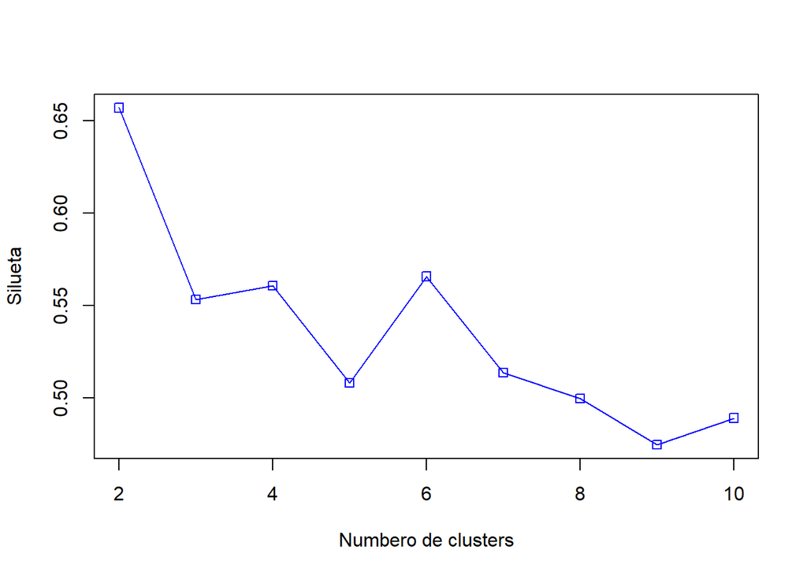

```r
# Primero se calculan las distancias entre los pares de puntos con la métrica "Gower" que viene por defecto.
d <- daisy(atributos)
resultados <- rep(0, 10)
# En un loop, calculamos los clústeres con los valores de K 2:10, extraemos las "predicciones" de clúster y hacemos el cálculo de su silueta. Haciendo el cálculo de la media del valor de la silueta, determinamos la calidad de la medición y así nos orientamos sobre el rango en el que la K óptima se encuentra.
for (i in c(2:10))
{
  fit           <- kmeans(atributos, i)
  y_cluster     <- fit$cluster
  sk            <- silhouette(y_cluster, d)
  resultados[i] <- mean(sk[,3])
}

# Por último, graficamos los resultados.

plot(2:10,resultados[2:10],type="o",col="blue",pch=0,xlab="Numbero de clusters",ylab="Silueta")
```

Sucede exactamente lo mismo que en el ejemplo introductorio, sabemos que el valor ideal es 3 pero en cambio nos devuelve 2. La diferencia con el ejemplo es que la posibilidad de 4 agrupamientos está muy cercana a 3 y sufre una caída mayor en 5. A partir de este análisis se intuye por tanto que el rango de clústeres está entre 2 y 4, pero antes probemos también con las otras medidas de K.

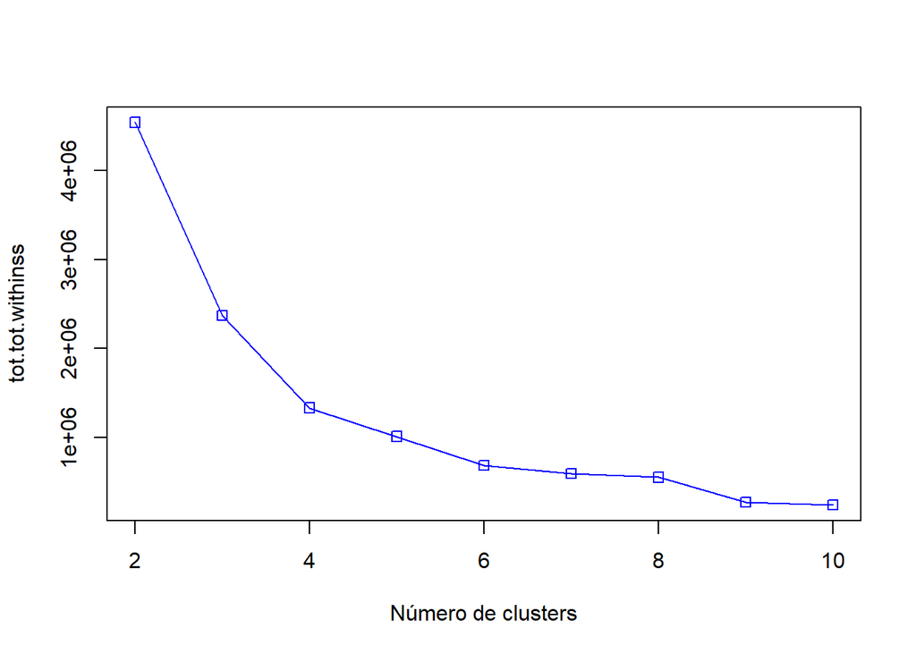

```r
# Sigue la misma estructura que el chunk anterior, la diferencia radica en la extracción del campo withinss en lugar del clúster asignado a cada elemento.

resultados <- rep(0, 10)
for (i in c(2:10))
{
  fit           <- kmeans(atributos, i)
  resultados[i] <- fit$tot.withinss
}
plot(2:10,resultados[2:10],type="o",col="blue",pch=0,xlab="Número de clusters",ylab="tot.tot.withinss")
```

Hacemos la última prueba para decantarnos por un rango de k con el método kmeansruns y los criterios asw y ch.

```r
library(fpc)
```

```r
fit_ch  <- kmeansruns(atributos, krange = 1:10, criterion = "ch")
fit_asw <- kmeansruns(atributos, krange = 1:10, criterion = "asw")

fit_ch$bestk
```

```
## [1] 10
```

```r
fit_asw$bestk
```

```
## [1] 2
```

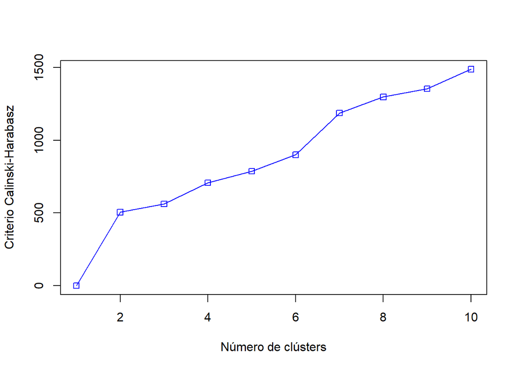

```r
plot(1:10,fit_ch$crit,type="o",col="blue",pch=0,xlab="Número de clústers",ylab="Criterio Calinski-Harabasz")
```

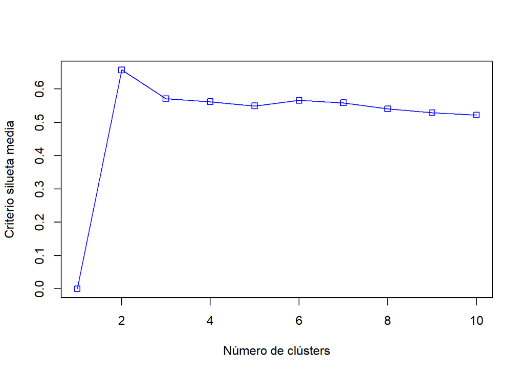

```r
plot(1:10,fit_asw$crit,type="o",col="blue",pch=0,xlab="Número de clústers",ylab="Criterio silueta media")
```

Antes de proseguir con unas conclusiones, nos llama la atención que según el criterio de Calinski-Harabasz no deje de mejorar cuantas más agrupaciones se hagan, así que vamos a repetir el análisis con valores de k aún mayores para asegurarnos de que no se trata de un over-fitting.

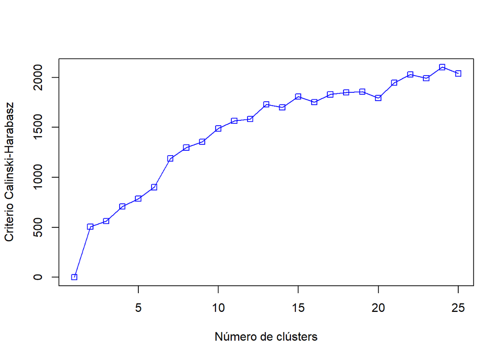

```r
fit_ch2  <- kmeansruns(atributos, krange = 1:25, criterion = "ch")
plot(1:25,fit_ch2$crit,type="o",col="blue",pch=0,xlab="Número de clústers",ylab="Criterio Calinski-Harabasz")
```

Lejos de ayudarnos a decantarnos por un rango u otro, el uso de distintos criterios nos confunde aún más en un valor adecuado para K. Estamos intentando no tomar decisiones influenciadas por el hecho de que sabemos que el valor óptimo de K, pero parece innegable que lo que el criterio ch así como el método withinss están haciendo es sobrespecializar un conjunto de datos que parece ser bastante disperso. Prueba de esto es el constante aumento del valor en el criterio ch, que tan sólo parece estabilizarse al llegar a valores entre 17 y 23, lo que en un dataset de 178 instancias es claramente demasiado alto. Aún así, hemos terminado de descartar el método ch debido a que:

“CH criterion is most suitable in case when clusters are more or less spherical and compact in their middle (such as normally distributed, for instance)1. Other conditions being equal, CH tends to prefer cluster solutions with clusters consisting of roughly the same number of objects.” https://stats.stackexchange.com/questions/52838/what-is-an-acceptable-value-of-the-calinski-harabasz-ch-criterion (Consultado el 20/04/2020)

Debido a esto realizaremos los análisis con valores entre 2 y 4, pero también haremos una pequeña prueba con el valor 9 para comprobar qué estaba sucediendo.

#### 3.2.1.3 Aplicación del algoritmo y medida de calidad

De la misma manera que hemos hecho en las pruebas, realizamos la clusterización con los 4 valores de k mencionados. Posteriormente vamos a proceder a medir la calidad de los cuatro modelos para así hacer una descripción del que tenga más calidad

```r
# Para hacer los cálculos de una manera simplificada y reutilizable, vamos a crear una función que mida la calidad de un modelo kmeans y a aplicarla sobre los cuatro modelos. Es importante tener en cuenta que el target se da en 3 valores, luego los modelos que no tengan una k igual a 3 tienen un handicap de inicio ya que no van a poder acertar la agrupación 3 (en el caso de k=2) o van a fallar todos los que agrupen en k>3.

calidad_kmeans <- function(modelo_kmeans, target){
  ### Función que mide el porcentaje de acierto de un modelo k-means. Sus atributos son el modelo (tal como resulta de la aplicación del algoritmo) y el target (vector o array) en el mismo orden. Es utilizable con cualquier valor de k, pero si k es mayor al número de casos reales, se considerará erróneo.###

  aciertos <- vector()
  # Este loop aisla los valores de la diagonal donde se encuentran los aciertos.
  for (i in 1:length(table(modelo_kmeans$cluster))){

# En caso de que haya un k mayor al número de casos reales, daremos por hecho que ha fallado.
    if (i<length(unique(target))){
    aciertos[i] <- table(modelo_kmeans$cluster, target)[i,i]
    } else {
      aciertos[i] <- 0
    }
  }
  # Se calcula el porcentaje de aciertos
  100*sum(aciertos)/length(modelo_kmeans$cluster)

}
```

```r
# Calculamos las cuatro posibilidades
set.seed(25)
vinos2 <- kmeans(atributos, 2)
vinos3 <- kmeans(atributos, 3)
vinos4 <- kmeans(atributos, 4)
vinos9 <- kmeans(atributos, 9)


paste("La calidad del modelo con k = 2 es:", calidad_kmeans(vinos2, datos[,1]), sep = " ")
```

```
## [1] "La calidad del modelo con k = 2 es: 7.30337078651685"
```

```r
paste("La calidad del modelo con k = 3 es:", calidad_kmeans(vinos3, datos[,1]), sep = " ")
```

```
## [1] "La calidad del modelo con k = 3 es: 53.9325842696629"
```

```r
paste("La calidad del modelo con k = 4 es:", calidad_kmeans(vinos4, datos[,1]), sep = " ")
```

```
## [1] "La calidad del modelo con k = 4 es: 7.30337078651685"
```

```r
paste("La calidad del modelo con k = 9 es:", calidad_kmeans(vinos9, datos[,1]), sep = " ")
```

```
## [1] "La calidad del modelo con k = 9 es: 12.9213483146067"
```

Hemos reproducido este último pedazo de código varias veces hasta que hemos conseguido un valor de k=3 aceptable que nos permita continuar con el ejercicio, pero insistimos en que el algoritmo kmeans no parece el adecuado para clasificar este dataset, que por otra parte sí que consideramos un dataset muy acertado para un ejercicio de clasificación dado que proviene de un conjunto de datos reales de complejidad alta.

#### 3.2.1.4 Descripción, interpretación y búsqueda de atributos relevantes.

amos a ver con un vistazo muy general dónde se encuentran patrones interesantes haciendo una gráfica con todas las dimensiones del dataset. Esta la vamos a colorear con las predicciones y con los tipos reales para ver cómo se ha comportado el algoritmo de clasificación.

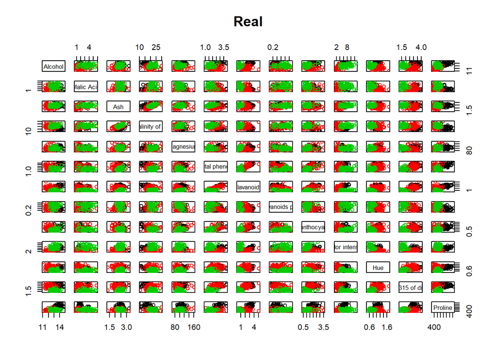

```r
plot(atributos, col=datos[,1], main = "Real")
```

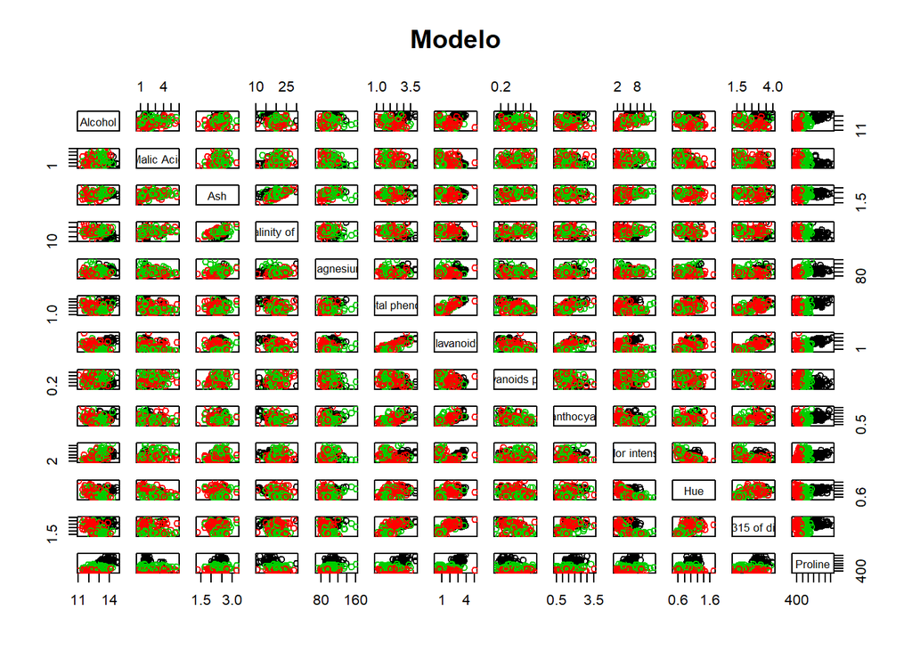

```r
plot(atributos, col=vinos3$cluster, main = "Modelo")
```

Lo primero que se tiene que notar en la gráfica con los datos reales, es que efectivamente el grupo negro está muy entremezclado con los otros dos, lo que ha debido complicar mucho la tarea de clasificación pues se homogeinizan los grupos. Pero sí que vemos que un atributo es relevante a la hora de determinar los grupos: Proline. Es el único de los atributos que en conjunción con el resto de suele mostrar grupos diferenaciados. Al comparar esta imagen con los resultados del modelo, podemos ver que el algoritmo ha sabido captar la importancia de la prolina en la separación de los grupos, dándole de hecho mucha más relevancia de la que tenía en los datos reales. Por otra parte, el tejido que crear el grupo negro al mezclarse con los otros dos, ha hecho que el algoritmo haya sido incapaz de separar los grupos.

Vamos a hacer una pequeña prueba para comprobar si no es conveniente incluir la prolina en el análisis clasificatorio por desvirtuar en demasía la asignación de grupos.

```r
vinos3.sinprolina <- kmeans(atributos[1:12], 3)
calidad_kmeans(vinos3.sinprolina, datos[,1])
```

```
## [1] 14.60674
```

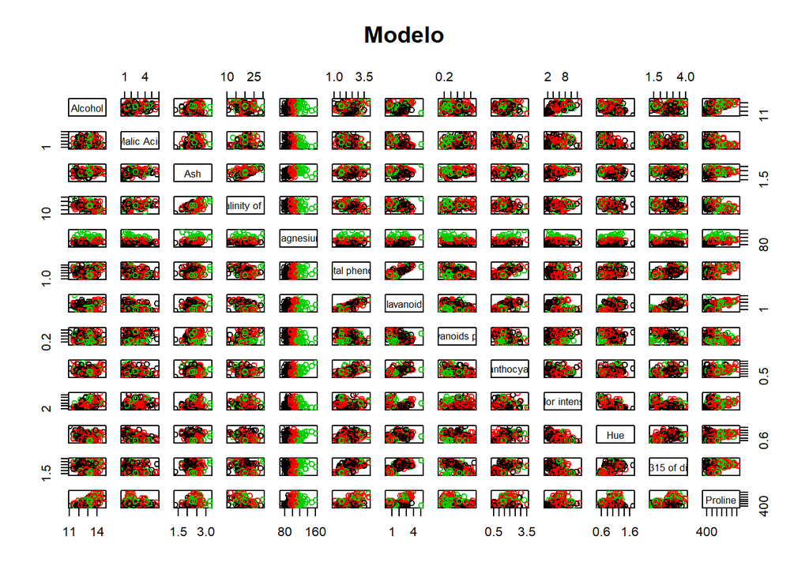

```r
plot(atributos, col=vinos3.sinprolina$cluster, main = "Modelo")
```

Como se puede apreciar, hace lo mismo pero con el magnesio. Es bastante probable que esto suceda debido a que la dispersión típica de estos dos factores sea mucho mayor, motivo por el que el algoritmo los considere los atributos definitorios de las distintas clases.

```r
apply(atributos, 2, sd, na.rm = TRUE)
```

```
##                      Alcohol                   Malic Acid
##                    0.8118265                    1.1171461
##                          Ash            Alcalinity of ash
##                    0.2743440                    3.3395638
##                    Magnesium                Total phenols
##                   14.2824835                    0.6258510
##                   Flavanoids        Nonflavanoids phenols
##                    0.9988587                    0.1244533
##              Proanthocyanics              Color intensity
##                    0.5723589                    2.3182859
##                          Hue OD280/OD315 of diluted wines
##                    0.2285716                    0.7099904
##                      Proline
##                  314.9074743
```

Efectivamente podemos apreciar que primero la prolina y después el magnesio están determinando las clases, así que vamos a escalar los datos para que el algoritmo haga uso de los 13 atributos de una forma más equitativa en lugar de priorizar el uso de uno solo.

```r
atributos.scaled <- scale(atributos)

vinos3.scaled <- kmeans(atributos.scaled, 3)
calidad_kmeans(vinos3.scaled, datos[,1])
```

```
## [1] 34.83146
```

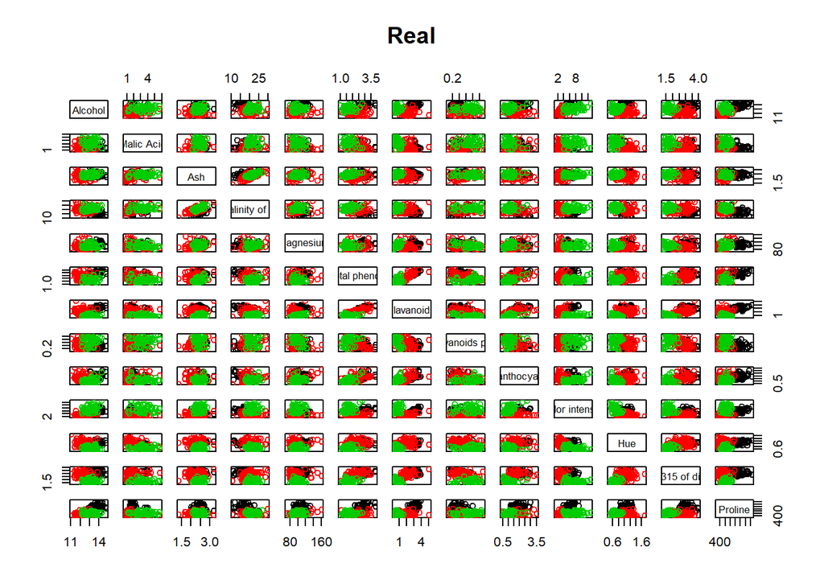

```r
plot(atributos, col=datos[,1], main = "Real")
```

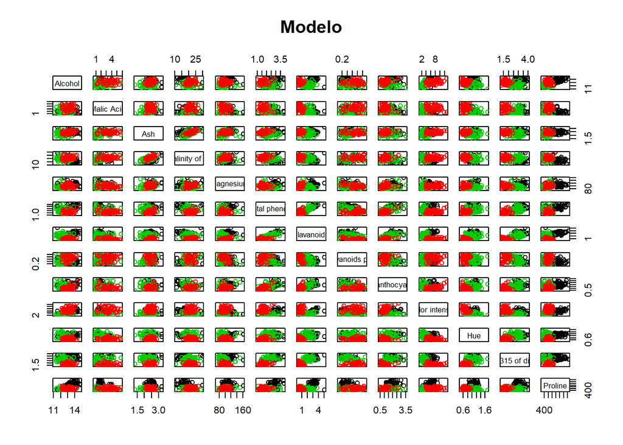

```r
plot(atributos, col=vinos3.scaled$cluster, main = "Modelo")
```

```r
cor(vinos3.scaled$cluster, datos[,1])
```

```
## [1] 0.5094378
```

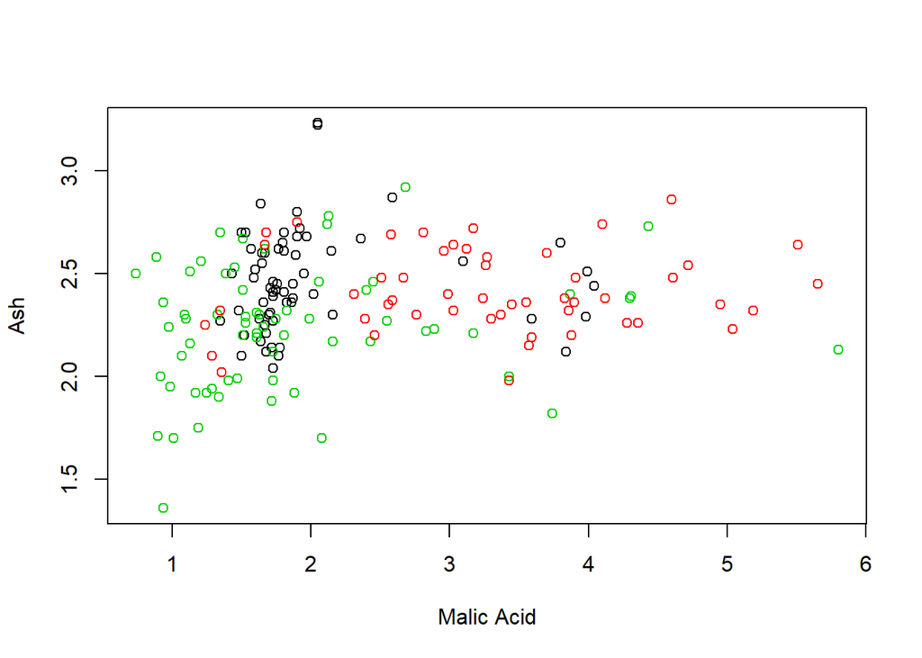

```r
plot(atributos[,c(2,3)], col=vinos3.scaled$cluster)
```

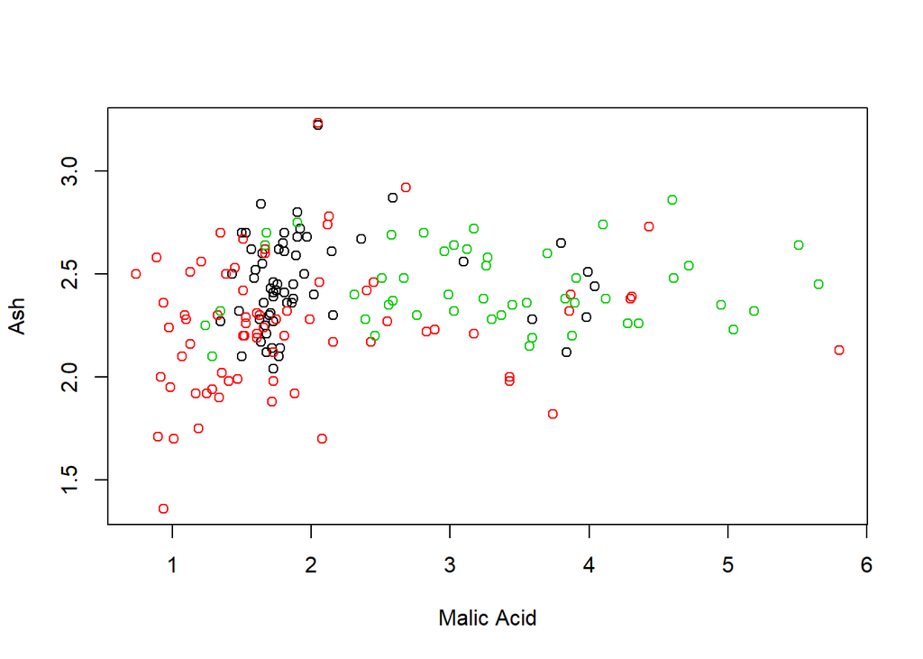

```r
plot(atributos[,c(2,3)], col=datos[,1])
```

Efectivamente los grupos 2 y 3 están intercambiados así que rehacemos los cálculos

```r
table(vinos3.scaled$cluster, datos[,1])
```

```
##
##      1  2  3
##   1 59  3  0
##   2  0  3 48
##   3  0 65  0
```

```r
100*(59+65+48)/178
```

```
## [1] 96.62921
```

Una calidad bastante alta de clasificación.

Lo último que nos quedaría por hacer es localizar los tres grupos a partir de argumentos representativos, para lo que vamos a ver qué variables se correlacionan entre sí.

```r
correlaciones <- cor(atributos.scaled)
correlaciones[(correlaciones < 0.6) & (correlaciones > -0.6) | correlaciones == 1] <- ""
correlaciones
```

```
##                              Alcohol             Malic Acid Ash
## Alcohol                      ""                  ""         ""
## Malic Acid                   ""                  ""         ""
## Ash                          ""                  ""         ""
## Alcalinity of ash            ""                  ""         ""
## Magnesium                    ""                  ""         ""
## Total phenols                ""                  ""         ""
## Flavanoids                   ""                  ""         ""
## Nonflavanoids phenols        ""                  ""         ""
## Proanthocyanics              ""                  ""         ""
## Color intensity              ""                  ""         ""
## Hue                          ""                  ""         ""
## OD280/OD315 of diluted wines ""                  ""         ""
## Proline                      "0.643720037178213" ""         ""
##                              Alcalinity of ash Magnesium Total phenols
## Alcohol                      ""                ""        ""
## Malic Acid                   ""                ""        ""
## Ash                          ""                ""        ""
## Alcalinity of ash            ""                ""        ""
## Magnesium                    ""                ""        ""
## Total phenols                ""                ""        ""
## Flavanoids                   ""                ""        "0.864563500095115"
## Nonflavanoids phenols        ""                ""        ""
## Proanthocyanics              ""                ""        "0.612413083780036"
## Color intensity              ""                ""        ""
## Hue                          ""                ""        ""
## OD280/OD315 of diluted wines ""                ""        "0.699949364791186"
## Proline                      ""                ""        ""
##                              Flavanoids          Nonflavanoids phenols
## Alcohol                      ""                  ""
## Malic Acid                   ""                  ""
## Ash                          ""                  ""
## Alcalinity of ash            ""                  ""
## Magnesium                    ""                  ""
## Total phenols                "0.864563500095115" ""
## Flavanoids                   ""                  ""
## Nonflavanoids phenols        ""                  ""
## Proanthocyanics              "0.652691768607515" ""
## Color intensity              ""                  ""
## Hue                          ""                  ""
```

[output cut: 15 more lines]

```
## Proline                      ""                  ""              ""
##                              OD280/OD315 of diluted wines Proline
## Alcohol                      ""                           "0.643720037178213"
## Malic Acid                   ""                           ""
## Ash                          ""                           ""
## Alcalinity of ash            ""                           ""
## Magnesium                    ""                           ""
## Total phenols                "0.699949364791186"          ""
## Flavanoids                   "0.787193901866951"          ""
## Nonflavanoids phenols        ""                           ""
## Proanthocyanics              ""                           ""
## Color intensity              ""                           ""
## Hue                          ""                           ""
## OD280/OD315 of diluted wines ""                           ""
## Proline                      ""                           ""
```

Tenemos las relaciones Total phenols con Flavanoids, OD280/OD315… con Flavanoids, queremos considerar la relación prolina-alcohol porque sabemos de su relevancia como clasificador y por último, queremos comprobar la relación entre los flavonoides y la prolina dado que son un argumento muy correlacionado con el resto y un argumento muy definitorio respectivamente.

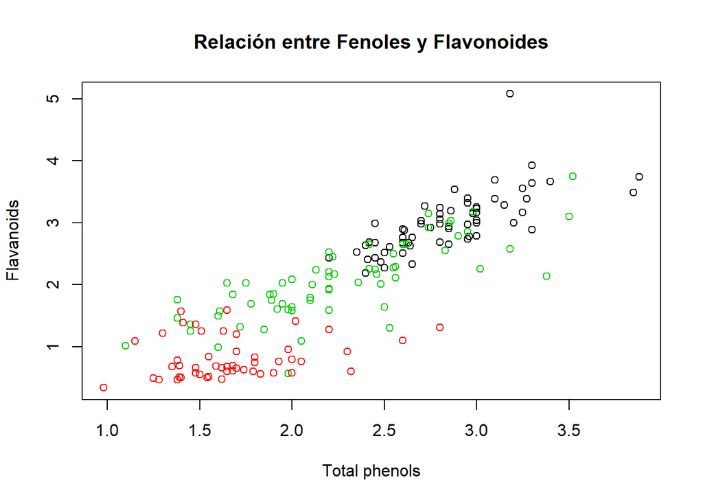

```r
plot(atributos[c(6,7)], col=vinos3.scaled$cluster, main = "Relación entre Fenoles y Flavonoides")
```

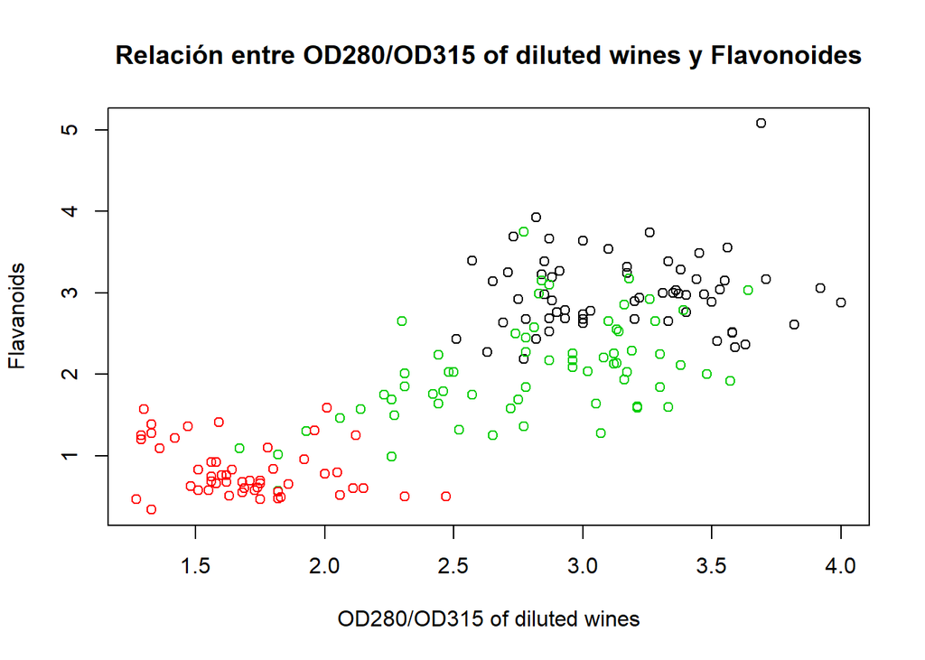

```r
plot(atributos[c(12,7)], col=vinos3.scaled$cluster, main = "Relación entre OD280/OD315 of diluted wines y Flavonoides")
```

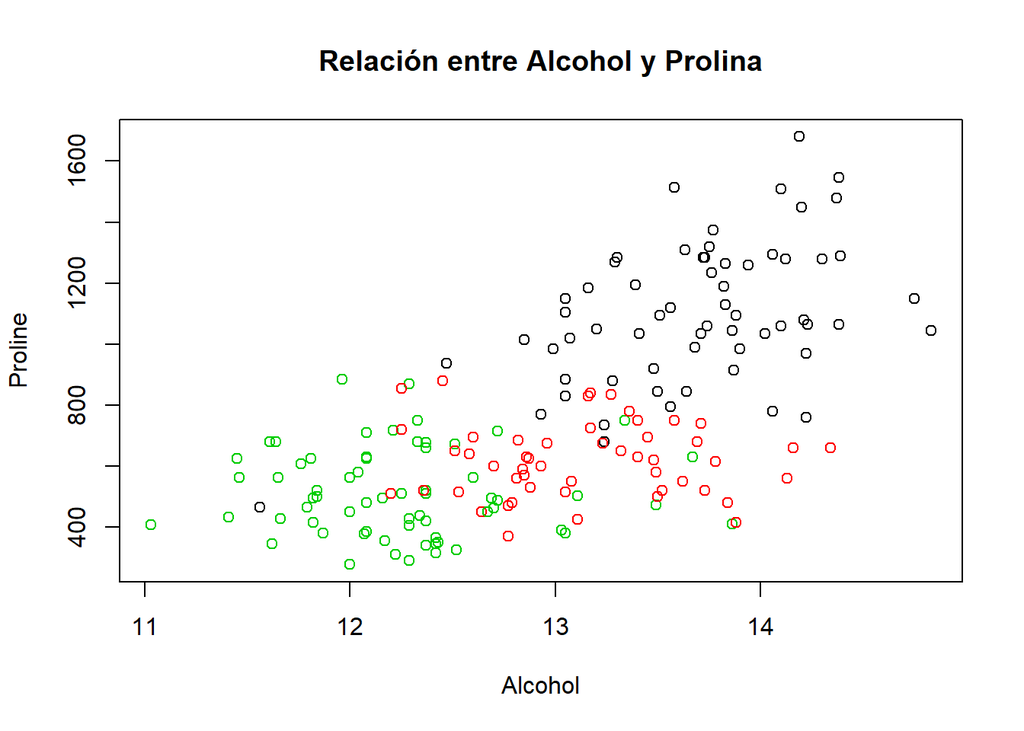

```r
plot(atributos[c(1,13)], col=vinos3.scaled$cluster, main = "Relación entre Alcohol y Prolina")
```

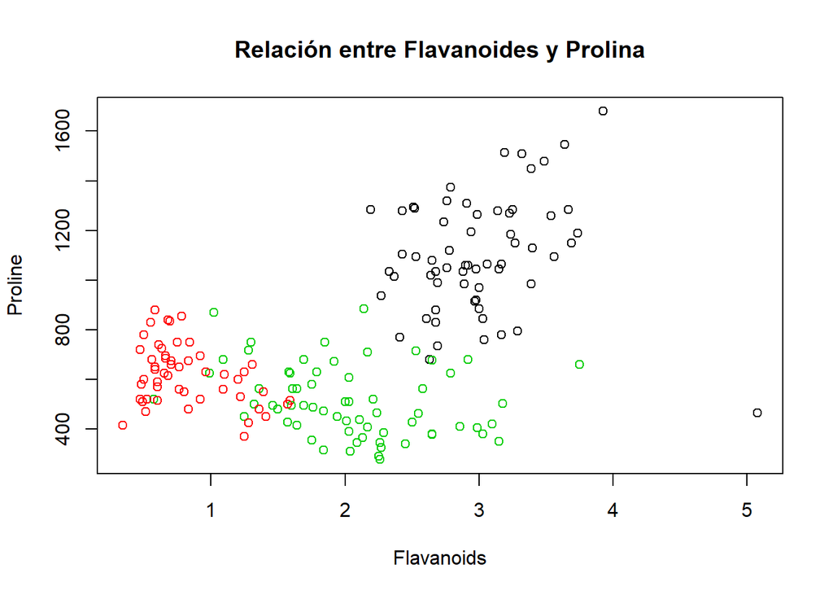

```r
plot(atributos[c(7,13)], col=vinos3.scaled$cluster, main = "Relación entre Flavanoides y Prolina")
```

## 3.3 Ejercicio 1.2

Buscar información sobre otros métodos de agregación diferentes al Kmeans. Partiendo del ejercicio anterior probar el funcionamiento de al menos 2 métodos diferentes y comparar los resultados obtenidos.

### 3.3.1 Respuesta 1.2

#### 3.3.1.1 Clasificación con PAM (Partitioning Around Medoids)

Es un algoritmo bastante similar a K-means, la mayor diferencia radica en que en lugar de clasificar a partir de centroides, esto se hace a partir de un elemento concreto del clúster denominado medoide. El resto del funcionamiento es el mismo, con una iniciación aleatoria cálculo de clúster y reubicación de los medoides hasta que la disposición no varía.

Para evitar el problema del número que se le asigna a cada clúster, vamos a continuar midiendo la calidad manualmente.

```r
library(cluster)
atributos.pam.scaled <- pam(x = atributos.scaled, k = 3, metric = "euclidean")
table(atributos.pam.scaled$clustering, datos[,1])
```

```
##
##      1  2  3
##   1 59 15  0
##   2  0 55  0
##   3  0  1 48
```

```r
100*(59+55+48)/178
```

```
## [1] 91.01124
```

#### 3.3.1.2 CLARA (Clustering Large Applications)

Otra evolución del algoritmo anterior. Clara está diseñado para trabajar con datasets de grandes dimensiones. Realiza el cálculo de los medoides con el algoritmo PAM sobre una muestra y después asigna el resto de elementos instancias. Este proceso se realiza en varias ocasiones para evitar la especialización en una muestra y finalmente utiliza los medoides con distancias menores.

```r
atributos.clara.scaled <- clara(atributos.scaled, k=3, metric = "euclidean")

table(atributos.clara.scaled$clustering, datos[,1])
```

```
##
##      1  2  3
##   1 59 10  0
##   2  0 60  0
##   3  0  1 48
```

```r
100*(59+60+48)/178
```

```
## [1] 93.82022
```